# Case: Churn

# Objective

Predict behavior to retain customers. You can analyze all relevant customer data and develop focused customer retention programs.

# Preparation

- Set random seed
- Load libraries
- Set working directory
- Load data

```r
set.seed(123)

library(ggplot2)
library(caret)
library(gbm)
library(rpart)
library(rpart.plot)

setwd("C:/Users/kfdek/Dropbox/Documents/R/Churn")

data <- read.csv("WA_Fn-UseC_-Telco-Customer-Churn.csv")
```

## Data exploration

```r
str(data)
```

```
'data.frame':   7043 obs. of  21 variables:
 $ customerID      : Factor w/ 7043 levels "0002-ORFBO","0003-MKNFE",..: 5376 3963 2565 5536 6512 6552 1003 4771 5605 4535 ...
 $ gender          : Factor w/ 2 levels "Female","Male": 1 2 2 2 1 1 2 1 1 2 ...
 $ SeniorCitizen   : int  0 0 0 0 0 0 0 0 0 0 ...
 $ Partner         : Factor w/ 2 levels "No","Yes": 2 1 1 1 1 1 1 1 2 1 ...
 $ Dependents      : Factor w/ 2 levels "No","Yes": 1 1 1 1 1 1 2 1 1 2 ...
 $ tenure          : int  1 34 2 45 2 8 22 10 28 62 ...
 $ PhoneService    : Factor w/ 2 levels "No","Yes": 1 2 2 1 2 2 2 1 2 2 ...
 $ MultipleLines   : Factor w/ 3 levels "No","No phone service",..: 2 1 1 2 1 3 3 2 3 1 ...
 $ InternetService : Factor w/ 3 levels "DSL","Fiber optic",..: 1 1 1 1 2 2 2 1 2 1 ...
 $ OnlineSecurity  : Factor w/ 3 levels "No","No internet service",..: 1 3 3 3 1 1 1 3 1 3 ...
 $ OnlineBackup    : Factor w/ 3 levels "No","No internet service",..: 3 1 3 1 1 1 3 1 1 3 ...
 $ DeviceProtection: Factor w/ 3 levels "No","No internet service",..: 1 3 1 3 1 3 1 1 3 1 ...
 $ TechSupport     : Factor w/ 3 levels "No","No internet service",..: 1 1 1 3 1 1 1 1 3 1 ...
 $ StreamingTV     : Factor w/ 3 levels "No","No internet service",..: 1 1 1 1 1 3 3 1 3 1 ...
 $ StreamingMovies : Factor w/ 3 levels "No","No internet service",..: 1 1 1 1 1 3 1 1 3 1 ...
 $ Contract        : Factor w/ 3 levels "Month-to-month",..: 1 2 1 2 1 1 1 1 1 2 ...
 $ PaperlessBilling: Factor w/ 2 levels "No","Yes": 2 1 2 1 2 2 2 1 2 1 ...
 $ PaymentMethod   : Factor w/ 4 levels "Bank transfer (automatic)",..: 3 4 4 1 3 3 2 4 3 1 ...
 $ MonthlyCharges  : num  29.9 57 53.9 42.3 70.7 ...
 $ TotalCharges    : num  29.9 1889.5 108.2 1840.8 151.7 ...
 $ Churn           : Factor w/ 2 levels "No","Yes": 1 1 2 1 2 2 1 1 2 1 ...
```

```r
summary(data)
```

```
      customerID      gender     SeniorCitizen    Partner    Dependents
 0002-ORFBO:   1   Female:3488   Min.   :0.0000   No :3641   No :4933
 0003-MKNFE:   1   Male  :3555   1st Qu.:0.0000   Yes:3402   Yes:2110
 0004-TLHLJ:   1                 Median :0.0000
 0011-IGKFF:   1                 Mean   :0.1621
 0013-EXCHZ:   1                 3rd Qu.:0.0000
 0013-MHZWF:   1                 Max.   :1.0000
 (Other)   :7037
     tenure      PhoneService          MultipleLines     InternetService
 Min.   : 0.00   No : 682     No              :3390   DSL        :2421
 1st Qu.: 9.00   Yes:6361     No phone service: 682   Fiber optic:3096
 Median :29.00                Yes             :2971   No         :1526
 Mean   :32.37
 3rd Qu.:55.00
 Max.   :72.00

             OnlineSecurity              OnlineBackup
 No                 :3498   No                 :3088
 No internet service:1526   No internet service:1526
 Yes                :2019   Yes                :2429




            DeviceProtection              TechSupport
 No                 :3095    No                 :3473
 No internet service:1526    No internet service:1526
 Yes                :2422    Yes                :2044




              StreamingTV              StreamingMovies
 No                 :2810   No                 :2785
 No internet service:1526   No internet service:1526
 Yes                :2707   Yes                :2732




           Contract    PaperlessBilling                   PaymentMethod
 Month-to-month:3875   No :2872         Bank transfer (automatic):1544
 One year      :1473   Yes:4171         Credit card (automatic)  :1522
 Two year      :1695                    Electronic check         :2365
                                        Mailed check             :1612



 MonthlyCharges    TotalCharges    Churn
 Min.   : 18.25   Min.   :  18.8   No :5174
 1st Qu.: 35.50   1st Qu.: 401.4   Yes:1869
 Median : 70.35   Median :1397.5
 Mean   : 64.76   Mean   :2283.3
 3rd Qu.: 89.85   3rd Qu.:3794.7
 Max.   :118.75   Max.   :8684.8
                  NA's   :11
```

```r
prop.table(table(data$Churn))
```

```
       No       Yes
0.7346301 0.2653699
```

## Data clean-up

- Remove customerID
- Convert SeniorCitizen to factor variable

```r
data <- data[, !colnames(data) == "customerID"]
data$SeniorCitizen <- factor(data$SeniorCitizen)
```

## Missing data

- Usual options: Impute missing values, remove rows with missing values, use model that can handle missing values
- Alternative: Remove feature TotalCharges which has all the missing data, because it is tenure * MonthlyCharges

```r
round(cor(data$tenure * data$MonthlyCharges, data$TotalCharges,
          use = "pairwise.complete.obs"), 3)
```

```
[1] 1
```

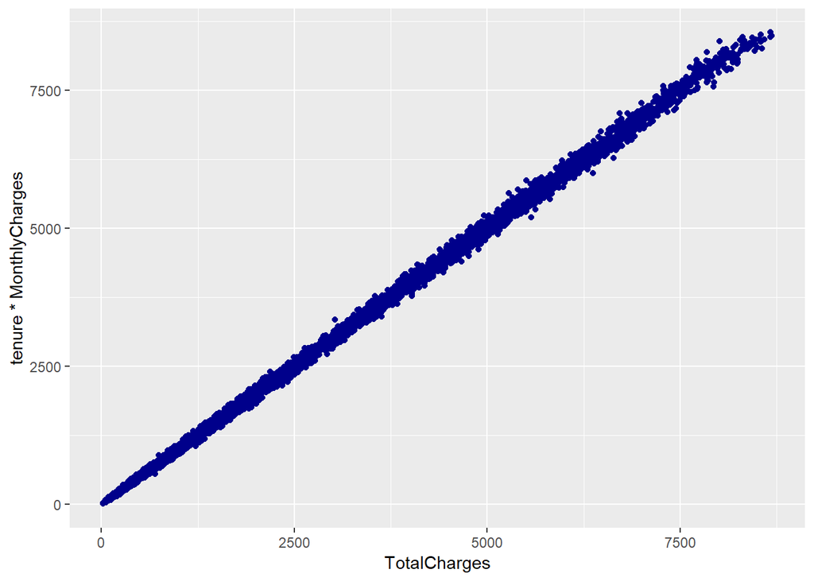

```r
ggplot(data, aes(x = TotalCharges,  y = tenure * MonthlyCharges)) +
  geom_point(color = "blue4")
```

```r
data <- data[, !colnames(data) == "TotalCharges"]
```

## Sanity Checks

- Calculate some tables of features with expected overlap
- Plot some expected relationships

```r
with(data, table(InternetService, OnlineSecurity))
```

```
               OnlineSecurity
InternetService   No No internet service  Yes
    DSL         1241                   0 1180
    Fiber optic 2257                   0  839
    No             0                1526    0
```

```r
with(data, table(PhoneService, MultipleLines))
```

```
            MultipleLines
PhoneService   No No phone service  Yes
         No     0              682    0
         Yes 3390                0 2971
```

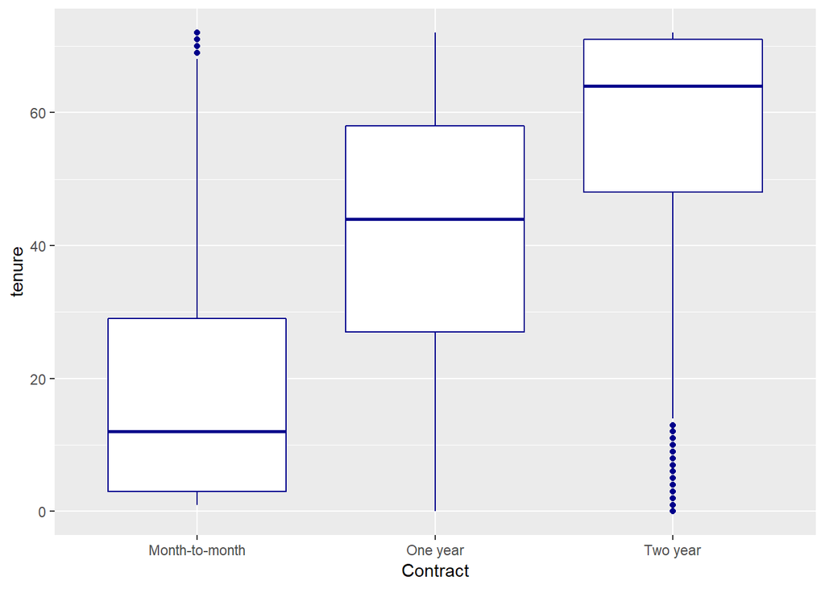

```r
ggplot(data, aes(x = Contract, y = tenure)) + geom_boxplot(color = "blue4")
```

# Analysis plan

## Preprocessing

- Scale data (mean = 0, sd = 1) to ensure features with high range of values do not dominate

## Evaluation

- Compare test set accuracy and feature importance with logistic regression baseline model and strong gradient boosting model

# Run models

## Split data in train and test sets using balanced split

```r
split <- createDataPartition(data$Churn, p = 0.3, list = F)
train <- data[-split, ]
test <- data[split, ]
```

## Baseline logistic regression model

```r
fit <- train(Churn ~ ., data = train, method = "glm", preProcess = c("center", "scale"),
             trControl = trainControl(method = "cv"))
paste("Accuracy:", round(sum(test$Churn == predict(fit, test)) / nrow(test), 3))
```

```
[1] "Accuracy: 0.799"
```

```
Accuracy: 0.799
```

```r
varImp(fit)
```

```
glm variable importance

  only 20 most important variables shown (out of 22)

                                       Overall
tenure                                 100.000
`ContractTwo year`                      60.870
`ContractOne year`                      52.109
`PaymentMethodElectronic check`         27.794
PaperlessBillingYes                     27.180
MultipleLinesYes                        24.094
SeniorCitizen1                          19.430
`InternetServiceFiber optic`            18.222
InternetServiceNo                       18.211
genderMale                              16.062
StreamingMoviesYes                      15.104
StreamingTVYes                          14.201
OnlineSecurityYes                       13.384
DependentsYes                           10.035
MonthlyCharges                           9.801
`PaymentMethodCredit card (automatic)`   9.564
DeviceProtectionYes                      6.783
TechSupportYes                           6.335
`PaymentMethodMailed check`              3.949
PhoneServiceYes                          3.897
```

## Baseline logistic regression model 2

- Remove correlated features to fix rank-deficiency warning

```r
fit <- train(Churn ~ ., data = train, method = "glm", preProcess = c("center", "scale", "corr"),
             trControl = trainControl(method = "cv"))
paste("Accuracy:", round(sum(test$Churn == predict(fit, test)) / nrow(test), 3))
```

```
[1] "Accuracy: 0.799"
```

```
Accuracy: 0.799
```

```r
varImp(fit)
```

```
glm variable importance

  only 20 most important variables shown (out of 22)

                                       Overall
tenure                                 100.000
`ContractTwo year`                      60.870
`ContractOne year`                      52.109
`PaymentMethodElectronic check`         27.794
PaperlessBillingYes                     27.180
MultipleLinesYes                        24.094
SeniorCitizen1                          19.430
`InternetServiceFiber optic`            18.222
`StreamingMoviesNo internet service`    18.211
genderMale                              16.062
StreamingMoviesYes                      15.104
StreamingTVYes                          14.201
OnlineSecurityYes                       13.384
DependentsYes                           10.035
MonthlyCharges                           9.801
`PaymentMethodCredit card (automatic)`   9.564
DeviceProtectionYes                      6.783
TechSupportYes                           6.335
`PaymentMethodMailed check`              3.949
PhoneServiceYes                          3.897
```

## Strong gradient boosting model

```r
fit <- train(Churn ~ ., data = train, method = "gbm", preProcess = c("center", "scale"),
             trControl = trainControl(method = "cv"), verbose = F)
paste("Accuracy:", round(sum(test$Churn == predict(fit, test)) / nrow(test), 3))
```

```
[1] "Accuracy: 0.807"
```

```
Accuracy: 0.807
```

```r
varImp(fit)
```

```
gbm variable importance

  only 20 most important variables shown (out of 29)

                                      Overall
tenure                               100.0000
InternetServiceFiber optic            59.7776
PaymentMethodElectronic check         35.6634
ContractTwo year                      26.2592
InternetServiceNo                      8.4449
ContractOne year                       8.3648
MonthlyCharges                         6.5582
OnlineSecurityYes                      5.6344
SeniorCitizen1                         4.7177
PaperlessBillingYes                    4.0332
MultipleLinesYes                       2.8625
TechSupportYes                         2.4289
StreamingMoviesYes                     1.8413
MultipleLinesNo phone service          1.1586
StreamingTVYes                         0.8876
OnlineBackupYes                        0.8826
PhoneServiceYes                        0.7850
DependentsYes                          0.3958
genderMale                             0.3858
PaymentMethodCredit card (automatic)   0.0000
```

## Decision tree model

```r
fit <- train(Churn ~ ., data = train, method = "rpart", preProcess = c("center", "scale"),
             trControl = trainControl(method = "cv"))
paste("Accuracy:", round(sum(test$Churn == predict(fit, test)) / nrow(test), 3))
```

```
[1] "Accuracy: 0.78"
```

```
Accuracy: 0.78
```

```r
varImp(fit)
```

```
rpart variable importance

  only 20 most important variables shown (out of 33)

                                       Overall
tenure                                 100.000
InternetServiceFiber optic              97.668
ContractTwo year                        78.365
PaymentMethodElectronic check           70.731
InternetServiceNo                       43.085
ContractOne year                        21.578
OnlineSecurityYes                       13.905
MonthlyCharges                           9.074
`OnlineBackupNo internet service`        0.000
`InternetServiceFiber optic`             0.000
PaperlessBillingYes                      0.000
`PaymentMethodCredit card (automatic)`   0.000
`MultipleLinesNo phone service`          0.000
SeniorCitizen1                           0.000
TechSupportYes                           0.000
PartnerYes                               0.000
`PaymentMethodMailed check`              0.000
DependentsYes                            0.000
genderMale                               0.000
OnlineBackupYes                          0.000
```

## Decision tree model 2

- Remove scaling to get non-scaled rules
  - For models where scaling is important an alternative is to scale predictions back to original mean and sd instead of removing preprocessing

```r
fit <- train(Churn ~ ., data = train, method = "rpart", trControl = trainControl(method = "cv"))
paste("Accuracy:", round(sum(test$Churn == predict(fit, test)) / nrow(test), 3))
```

```
[1] "Accuracy: 0.78"
```

```
Accuracy: 0.78
```

```r
varImp(fit)
```

```
rpart variable importance

  only 20 most important variables shown (out of 33)

                                      Overall
tenure                                100.000
InternetServiceFiber optic             97.668
ContractTwo year                       78.365
PaymentMethodElectronic check          70.731
InternetServiceNo                      43.085
ContractOne year                       21.578
OnlineSecurityYes                      13.905
MonthlyCharges                          9.074
TechSupportYes                          0.000
PaperlessBillingYes                     0.000
StreamingTVYes                          0.000
PhoneServiceYes                         0.000
`TechSupportNo internet service`        0.000
`StreamingMoviesNo internet service`    0.000
`InternetServiceFiber optic`            0.000
`ContractOne year`                      0.000
`PaymentMethodMailed check`             0.000
`DeviceProtectionNo internet service`   0.000
`OnlineSecurityNo internet service`     0.000
`OnlineBackupNo internet service`       0.000
```

## Data visualization

- Plot tree
- Plot relationships between Churn and features

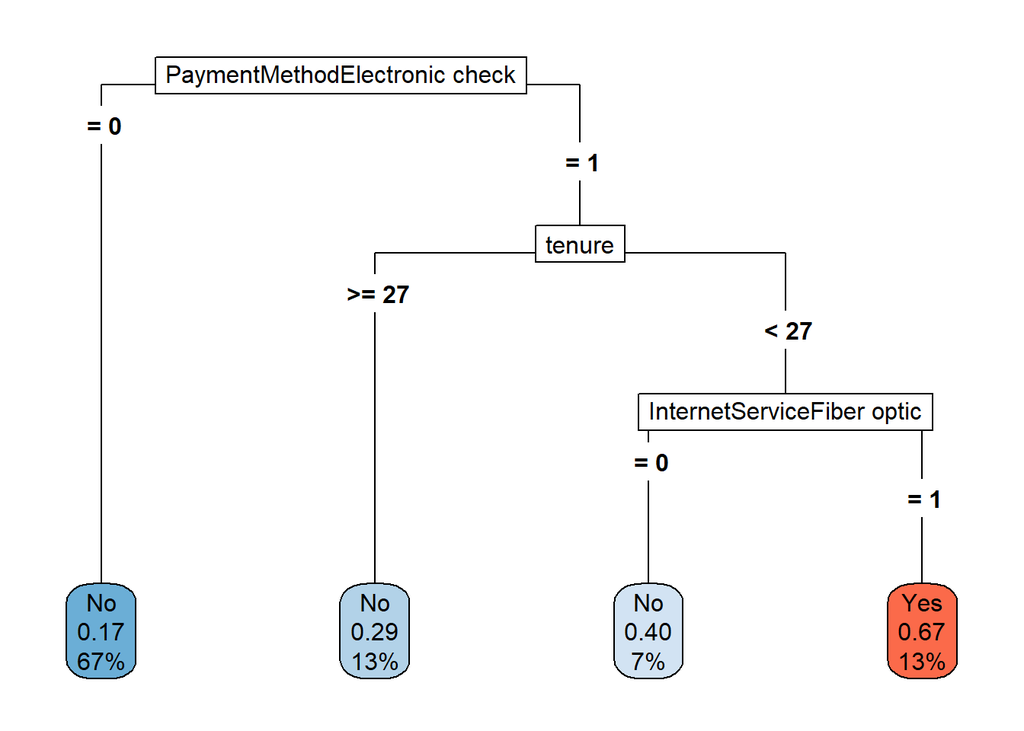

```r
rpart.plot(fit$finalModel, type = 5, cex = 1, box.palette = "BuRd")
```

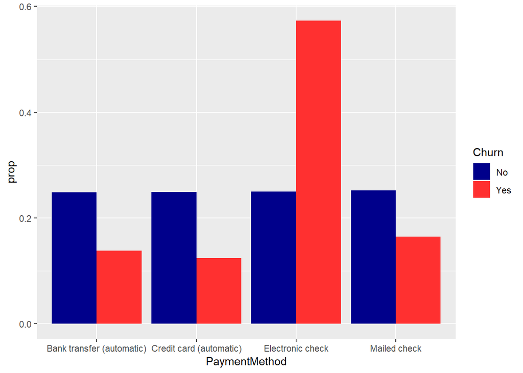

```r
ggplot(data, aes(x = PaymentMethod, y = ..prop.., group = Churn, fill = Churn)) +
  geom_bar(position = "dodge") + scale_fill_manual(values = c("blue4", "firebrick1"))
```

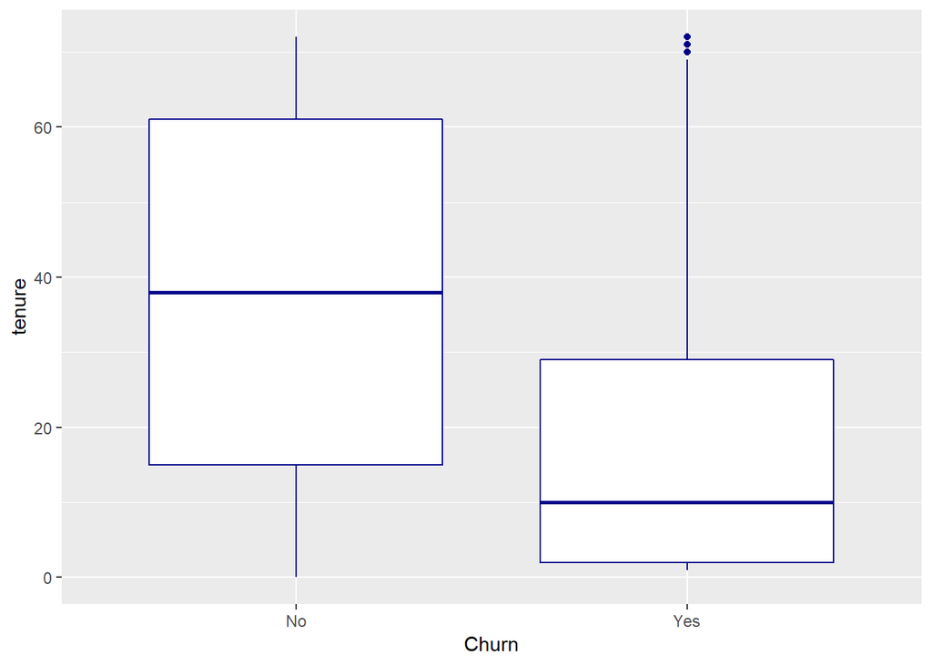

```r
ggplot(data, aes(x = Churn, y = tenure)) + geom_boxplot(color = "blue4")
```

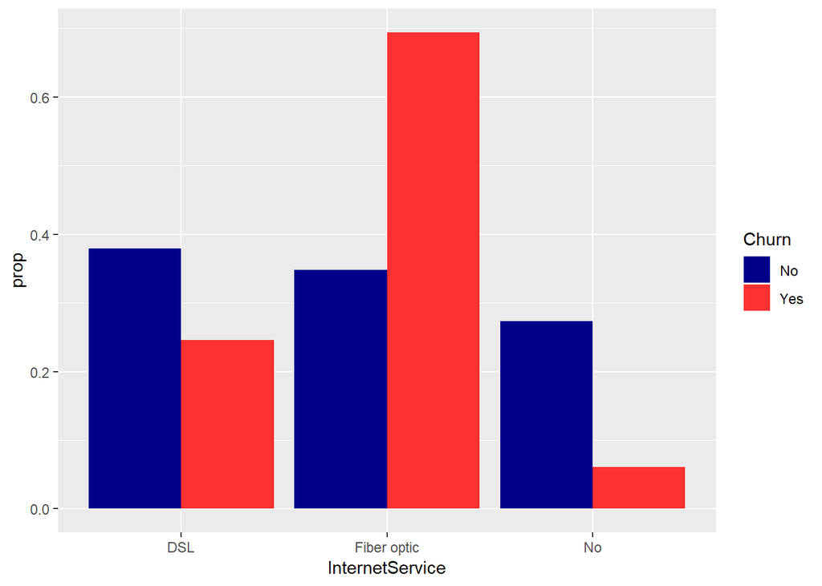

```r
ggplot(data, aes(x = InternetService, y = ..prop.., group = Churn, fill = Churn)) +
  geom_bar(position = "dodge") + scale_fill_manual(values = c("blue4", "firebrick1"))
```

## Save data

```r
save(data, fit, test, file = "data.RData")
```

## Customer retention strategies

- Target customers that pay with electronic checks
- Target customers that have a tenure < 27 that pay with electronic checks
- Target customers that have fiber optic internet service, a tenure < 27 and pay with electronic checks

## Future improvements

- Ask data generators/curators if SeniorCitizen label 1 corresponds to customer being a senior citizen
- Ask data generators/curators why TotalCharges differs a little bit from tenure * MonthlyCharges
- Improve decision tree
  - evaluate bootstrapping instead of cross-validation
  - evaluate parameters for splitting
  - evaluate parameters for pruning
- Improve visualizations and app
- Secondary objective: Improve prediction of customers that might churn at the cost of minor increase in false positives (and decreased accuracy) using ROC/AUC